## Getting started

Before starting, you should install R and Rstudio on your computer. R can be downloaded from here: https://cran.r-project.org/mirrors.html. and RStudio can be downloaded from https://rstudio.com/products/rstudio/. Both are free. Once both programs are installed, open RStudio, and either open the .Rmd file practical exercises.Rmd or create a new RMarkdown document File/New File/R Notebook.

Load the libraries we need for this exercise.

```r
#install.packages(c('lubridate', 'RCurl','devtools','xtable','knitr','htmlTable','coda','rmdformats','httr'))
#library(devtools)
#devtools::install_github('https://github.com/weinbergerlab/InterventionEvaluatR')
#install_version("future", version = "1.19.1", repos = "http://cran.us.r-project.org")


library(lubridate)
library(RCurl)
library(knitr)
library(htmlTable)
library(InterventionEvaluatR)
library(coda)
library(rmdformats)
library(httr)
library(pbapply)
library(xtable)
```

## Introduction to the Example

In this example, you will learn about: 1. How to perform visual quality checks 2. How to fit models to the data to evaluate vaccine impact 3. How to interpret and describe the results

In this example, we will analyze data on deaths due to pneumonia in South Africa to evaluate the impact of PCVs. This example is based on the analysis by Kleynhans et al (PLOS Medicine 2021), available from https://pubmed.ncbi.nlm.nih.gov/33591995/. The data and code for the original study can be found at https://github.com/weinbergerlab/south_africa_kleynhans

South Africa introduced PCV7 in 2009. Estimating the impact of the vaccine on mortality is especially challenging in this setting because of unrelated changes in the incidence of HIV and the rollout of antiretroviral therapies, both of which had a strong influence on death rates due to pneumonia. There are a number of potential control causes of death that could be used to adjust for these trends.

## Read in and explore data

```r
d2 <- read.csv('./Data/RSA.csv') #imports file into R and saves as object 'd2'
```

### Look at the first few lines

```r
head(d2)
```

```
##         date                 age Inf. Pneum A20_B99_excl_bac A16_A19 A16
## 1 1999-01-01 Less than one month    0    63                5       0   0
## 2 1999-02-01 Less than one month    0    55               12       0   0
## 3 1999-03-01 Less than one month    0    68                7       0   0
## 4 1999-04-01 Less than one month    0    59                3       0   0
## 5 1999-05-01 Less than one month    0    71                2       0   0
## 6 1999-06-01 Less than one month    0    54                1       0   0
##   A17 A18 A19 A20_A48 A39 A50_A79 A80_B34 B05_B06 B20_B24 B35_B49 B45
## 1   0   0   0       0   0       2       2       0       1       0   0
## 2   0   0   0       1   0       5       2       0       3       0   0
## 3   0   0   0       0   0       4       0       0       2       0   0
## 4   0   0   0       0   0       0       1       0       1       1   0
## 5   0   0   0       0   0       1       0       0       1       0   0
## 6   0   0   0       0   0       0       1       0       0       0   0
##   B50_B89 B99 C00_D49 D50_D89 A20_B99_a_D50_D89 E00_E89 E10_E14 E40_E46
```

[output cut: 34 more lines]

Make sure R knows that the ‘date’ variable is a date. We tell it tha the date has a 4 digit year (%Y), a 2 digit month (%m), and 2 digit day (%d), separated by dashes.

```r
d2$date<-as.Date(d2$date,"%Y-%m-%d")
```

### Exclude certain covariates

```r
exclude_covar <- c("denom", "A20_B99_excl_bac", "A16", "A17", "A18", "A19", "R00_R09", "R10_R19", "R20_R39", "R40_R49", "R50_R69", "R70_R94", "R95_R99", "D50_D89")

d2 <- d2[,-which(names(d2) %in% exclude_covar)]

d2 <-
  d2[, c(
    'date',
    'age',
    'Pneum',
    "A16_A19",
    "A20_A48",
    "A39",
    "A50_A79",
    "A80_B34",
    "B05_B06",
    "B20_B24",
    "B35_B49" ,
    "B45",
    "B50_B89",
    "B99" ,
    "C00_D49" ,
    "A20_B99_a_D50_D89" ,
    "E00_E89"      ,
    "E10_E14"  ,
    "E40_E46",
    "F01_F99"   ,
    "G05_G99"   ,
    "H00_H99_excl_cj_om",
    "I00_I99"  ,
    "I60_I64"   ,
    "K00_K95"   ,
    "K35"  ,
    "K80"   ,
    "L00_L99"       ,
    "M00_M99"   ,
    "N00_N99"  ,
    "N39"     ,
    "O00_O99"       ,
    "P00_P15" ,
    "P05_P07",
    "Q00_Q99"      ,
    "R00_R99"   ,
    "S00_T88"  ,
    "V01_Y99"
  )]
```

Subset to a few age groups for analysis

```r
d2 <- d2[d2$age %in% c('1-11 months', '1-4 years','65-79 years'),]
```

## Plot your time series

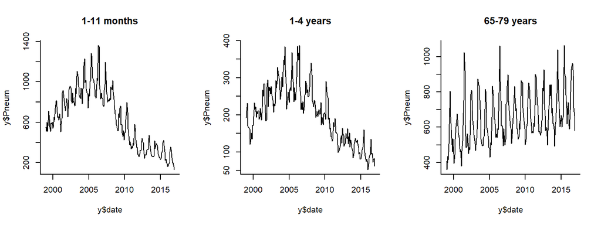

```r
par(mfrow=c(1,3))
d2.spl <- split(d2, factor(d2$age))
lapply(names(d2.spl), function(x){
  y <- d2.spl[[x]]
 plot(y$date,y$Pneum,  #names of variable
      type='l', #'l' for line plot
      bty='l' ,#turn off the top and right border
      main=x
      )
})
```

## Set parameters for analysis with InterventionEvaluatR

Here we need to set a few parameters. We use the evaluatr.init() function to specify the name of the dataset, the date at which the vaccine is introduced, the date at which we want to begin evaluating the vaccine (typically 1-2 year after vaccine introduction). We also provide some information on the dataset, sch as whether the data are monthly or quarterly (n_seasons), the variable names for the grouping variable, the date variable, the outcome variable, and the denominator variable (if any). You can also set the number of interations for the MCMC. the default is to use a burn-in period of 5000 iterations and to sample 10,000 iterations afterthe burn in. This is a decent place to start. After evaluating model convergence (see below), you might want to increase the burn-in period.

```r
d2$one <- 1

analysis <- evaluatr.init(
  country = "South Africa", data = d2,
  post_period_start = "2009-04-01", #First 'post-intervention' month is April 2009
  eval_period_start = "2012-01-01", #We ignore first few years to allow for vaccine ramp up
  eval_period_end = "2016-12-01", #The evaluation period lasts 5 years
  n_seasons = 12, #This is monthly data, so select 12
  year_def = "cal_year", # we are in southern hemisphere, so aggregate results by calendar year (Jan-Dec)
  group_name = "age",  #Strata categry name
  date_name = "date", #Date variable name
  outcome_name = "Pneum", #Outcome variable name
  denom_name = "one" , #Denominator variable name
  log.covars=TRUE, #log-transform the covariates
  set.burnN=5000,
  ridge=F, #Ridge regression---faster version
  error_dist= 'iid',
  set.sampleN=10000
)
set.seed(1)

analysis <- readRDS('./Results/analysis_post_run_SA.rds') #reads in analysis object that was modified after running SC
```

## Run a simple analysis controlling for 1 control variable at a time

Before getting into more complicated analyses, we will first try to fit a simple Poisson regression model (with overdispersion) where we adjust for seasonality and 1 control variable at a time. this allows us to see how the use of different controls influences the results

```r
# glmer_results= evaluatr.univariate(analysis)
```

```r
#saveRDS(glmer_results,'./Results/univariate_results_SA.rds')
glmer_results  <- readRDS('./Results/univariate_results_SA.rds')
```

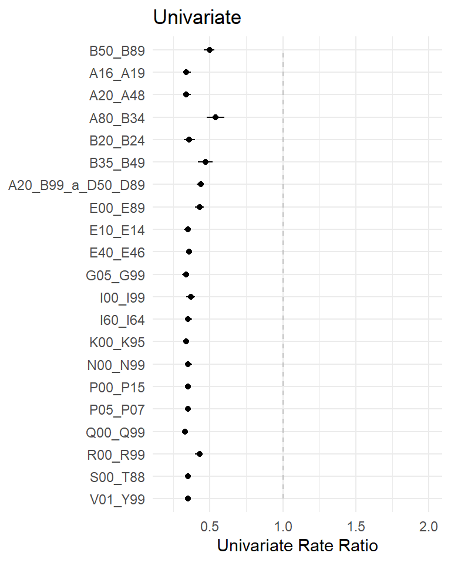

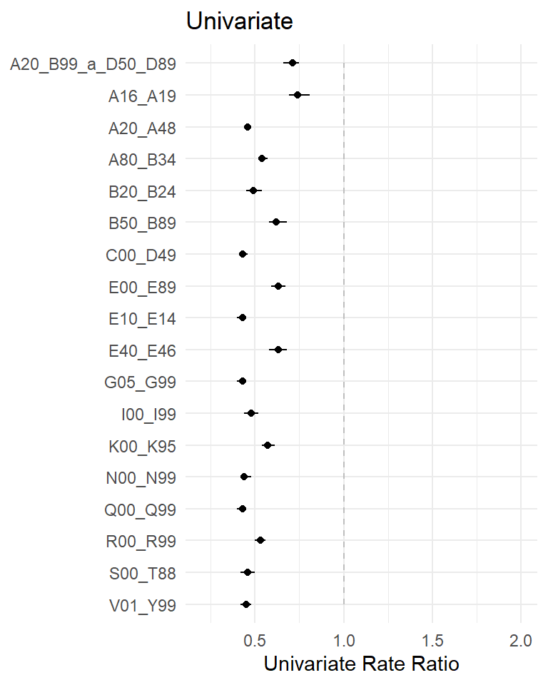

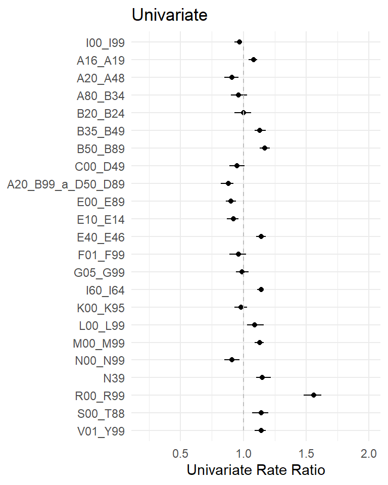

```r
par(mar=c(4,5,1,1)) #fix margins
group.labels<-as.character(unique(analysis$input_data[,analysis$group_name]))
lapply(glmer_results,evaluatr.univariate.plot)
```

## Run Synthetic control analysis

For teaching purposes, this code has been pre-run since it takes some time and computational resources.

```r
#impact_results = evaluatr.impact(analysis)
```

Load the pre-run results

```r
#saveRDS(impact_results,'./Results/SA_sc.rds')
impact_results <- readRDS('./Results/SA_sc.rds')
```

### Compare estimates from different models

```r
results.table<- cbind.data.frame(
  #impact_results$best$rr_mean_intervals,
  impact_results$full$rr_mean_intervals,
  impact_results$time$rr_mean_intervals,
  #impact_results$time_no_offset$rr_mean_intervals,
  impact_results$its$rr_mean_intervals,
  impact_results$pca$rr_mean_intervals)
  table<-xtable(results.table)
  htmlTable(table)
```

|  | Synthetic controls Estimate (95% CI) | Time trend Estimate (95% CI) | Classic ITS (95% CI) | STL+PCA Estimate (95% CI) |
| --- | --- | --- | --- | --- |
| 1-11 months | 0.68 (0.61, 0.74) | 0.25 (0.22, 0.28) | 0.25 (0.23, 0.28) | 0.32 (0.29, 0.34) |
| 1-4 years | 0.77 (0.71, 0.83) | 0.32 (0.28, 0.36) | 0.32 (0.28, 0.36) | 1.35 (1.21, 1.51) |
| 65-79 years | 0.97 (0.93, 1.15) | 0.9 (0.84, 0.95) | 0.9 (0.85, 0.95) | 0.9 (0.85, 0.96) |

### Cases averted

How many cases were prevented from the time of vaccine introduction to the last time point in each stratum (+/- 95% CrI)? You can modify the number ‘last.point’ to pull out the cumulative number of cases at any point in the time series. In this case we are printing results fromthe SC model

```r
last.point<-dim(impact_results$full$cumsum_prevented)[1]
cum.prevented<-impact_results$full$cumsum_prevented[last.point,,]
```

Format and print table

```r
cum1<- round(t(cum.prevented))
cum2<- paste0(cum1[,'50%'], ' (', cum1[,'2.5%'],', ',cum1[,'97.5%'],')')
cum3<-cbind.data.frame(row.names(cum1), cum2)
names(cum3)<-c('Stratum','Cases Averted (95% CrI)')
  htmlTable(cum3, align='l')
```

|  | Stratum | Cases Averted (95% CrI) |
| --- | --- | --- |
| 1 | 1-11 months | 12552 (9274, 16936) |
| 2 | 1-4 years | 3269 (2322, 4272) |
| 3 | 65-79 years | 1675 (-6543, 4051) |

### Number of variables selected in SC analysis

```r
model_size = data.frame(t(analysis$model_size))
htmlTable(model_size, align='c')
```

|  | X1.11.months | X1.4.years | X65.79.years |
| --- | --- | --- | --- |
| 1 | 4.87 | 3.34 | 1.33 |

### Inclusion Probabilities

```r
incl_probs <- NULL
for (group in analysis$groups) {
  incl_prob <- impact_results$full$groups[[group]]$inclusion_probs[-c(1:(analysis$n_seasons - 1)), ]
  incl_prob <- incl_prob[order(-incl_prob$inclusion_probs), ]
  incl_prob <- incl_prob[c(1:3), ]
  incl_prob2 <- round(incl_prob[, 2],2)
  incl_prob_names <- incl_prob[, 1]
  incl_prob3 <- data.frame("Group" = group, "Greatest Inclusion Variable" = incl_prob_names[1], "Greatest Inclusion Probability" = incl_prob2[1], "Second Greatest Inclusion Variable" = incl_prob_names[2], "Second Greatest Inclusion Probability" = incl_prob2[2], "Third Greatest Inclusion Variable" = incl_prob_names[3], "Third Greatest Inclusion Probability" = incl_prob2[3], check.names = FALSE)
  incl_probs <- rbind(incl_probs, incl_prob3)
}
rownames(incl_probs) <- NULL
```

Here we can see which variables received the most weight in the models for each strata. Values range from 0-1, with values closer to 1 indicating that the variable was included in a larger proportion of the variable combinations that were tested A value of 1 would indicate that the variable was always included in the model, a value of 0.48 would indicate the variable was included in 48% of the models that were tested.

```r
htmlTable(incl_probs)
```

|  | Group | Greatest Inclusion Variable | Greatest Inclusion Probability | Second Greatest Inclusion Variable | Second Greatest Inclusion Probability | Third Greatest Inclusion Variable | Third Greatest Inclusion Probability |
| --- | --- | --- | --- | --- | --- | --- | --- |
| 1 | 1-11 months | B50_B89 | 1 | R00_R99 | 0.91 | E40_E46 | 0.85 |
| 2 | 1-4 years | A16_A19 | 1 | E00_E89 | 0.87 | A20_B99_a_D50_D89 | 0.52 |
| 3 | 65-79 years | I00_I99 | 0.98 | R00_R99 | 0.08 | C00_D49 | 0.04 |

### Sensitivity analysis

In the sensitivity analyses, we re-run the synthetic controls analysis, but sequentially drop the top 1,2, or 3 variables that were most influential (received the most weight) in the original analysis. This allows us to evaluate whether the results are sensitive to the inclusion of a specific variable

Load the pre-run results

```r
  #saveRDS(sensitivity_results, './Results/sensitivity_SA.rds')
  #saveRDS(analysis, './Results/analysis_post_run_SA.rds')

  sensitivity_results <- readRDS('./Results/sensitivity_SA.rds')
```

The purpose of this analysis is to evaluate the sensitivity of the synthetic controls results to the inclusion of specific control variables. The model is first fit with all variables, then the top-weighted variable is excluded, and the model is re-run. If the results change drastically after dropping 1 variable, this indicates that that variable is highly influential on the results. If the results don’t change, this indicates that the results are robust to the exclusion of that variable (this assumes that the variable that is excluded received a decent amount of weight prior to exclusion)

```r
if (exists("sensitivity_results")) {
  htmlTable(sensitivity_results$sensitivity_table_intervals)
}
```

|  | Estimate (95% CI) | Top Control 1 | Inclusion Probability of Control 1 | Control 1 Estimate (95% CI) | Top Control 2 | Inclusion Probability of Control 2 | Control 2 Estimate (95% CI) | Top Control 3 | Inclusion Probability of Control 3 | Control 3 Estimate (95% CI) |
| --- | --- | --- | --- | --- | --- | --- | --- | --- | --- | --- |
| 1-11 months | 0.68 (0.61, 0.74) | B50_B89 | 1 | 0.65 (0.59, 0.72) | R00_R99 | 0.91 | 0.67 (0.6, 0.73) | E40_E46 | 0.85 | 0.59 (0.55, 0.65) |
| 1-4 years | 0.77 (0.71, 0.83) | A16_A19 | 1 | 0.69 (0.61, 0.8) | E00_E89 | 0.87 | 0.67 (0.61, 0.75) | A20_B99_a_D50_D89 | 0.52 | 0.66 (0.6, 0.73) |
| 65-79 years | 0.97 (0.93, 1.15) | I00_I99 | 0.98 | 1.12 (0.91, 1.4) | R00_R99 | 0.08 | 1.09 (0.92, 1.13) | C00_D49 | 0.04 | 1.09 (0.9, 1.13) |

## Generate and save the plots

### Plot the results for 1 age group

### First look at the results from the synthetic controls model for 1 age group.

In the 1-11 month olds, we can clearly see the observed data going below the expected values after vaccination. This suggests that pneumonia is declining more than would be expected based on the decline in the control diseases.

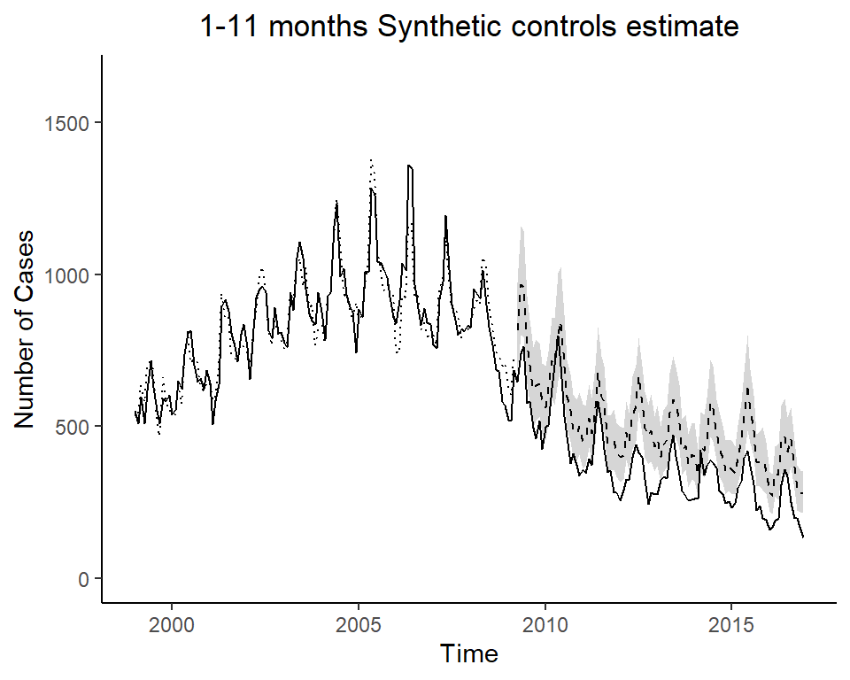

```r
      plots$groups[["1-11 months"]]$pred_full
```

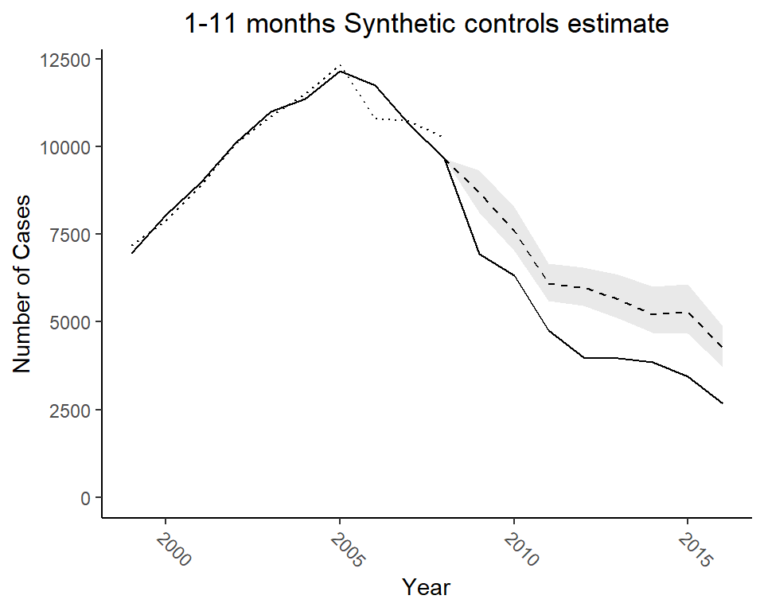

```r
      plots$groups[["1-11 months"]]$pred_full_agg
```

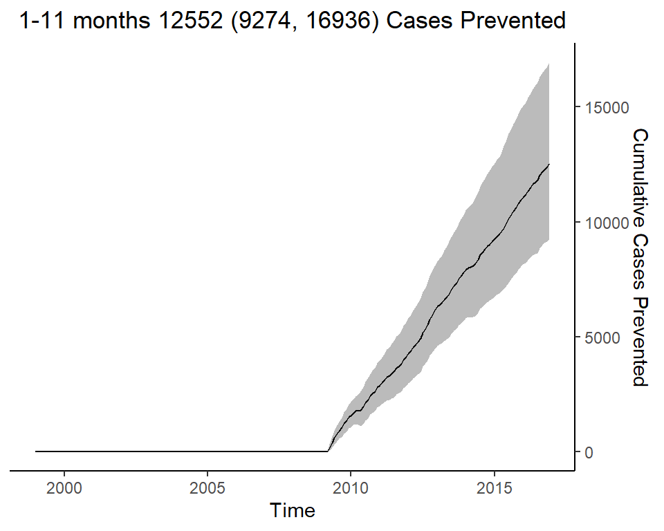

```r
      plots$groups[["1-11 months"]]$cumsum_prevented
```

## Printing plots for all models and age groups

We instead might want to just print everything for all age groups and models. We can use the following code to do that

## Plot Observed vs expected yearly time series

For the synthetic controls analyses, we can see clear effects of PCV in children (where the vaccine is used), but not in adults. This suggests that the indirect effects of PCVs, observed in other populations, are not protecting adults from death in this population. It is also clear here why the unadjusted time trend model fails due to the non-linear shape of the trend in the pre-vaccine period.

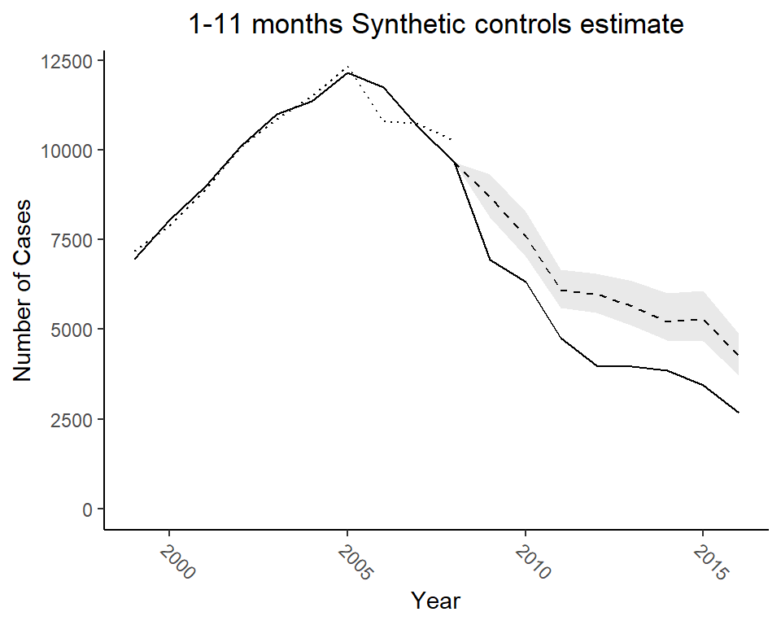

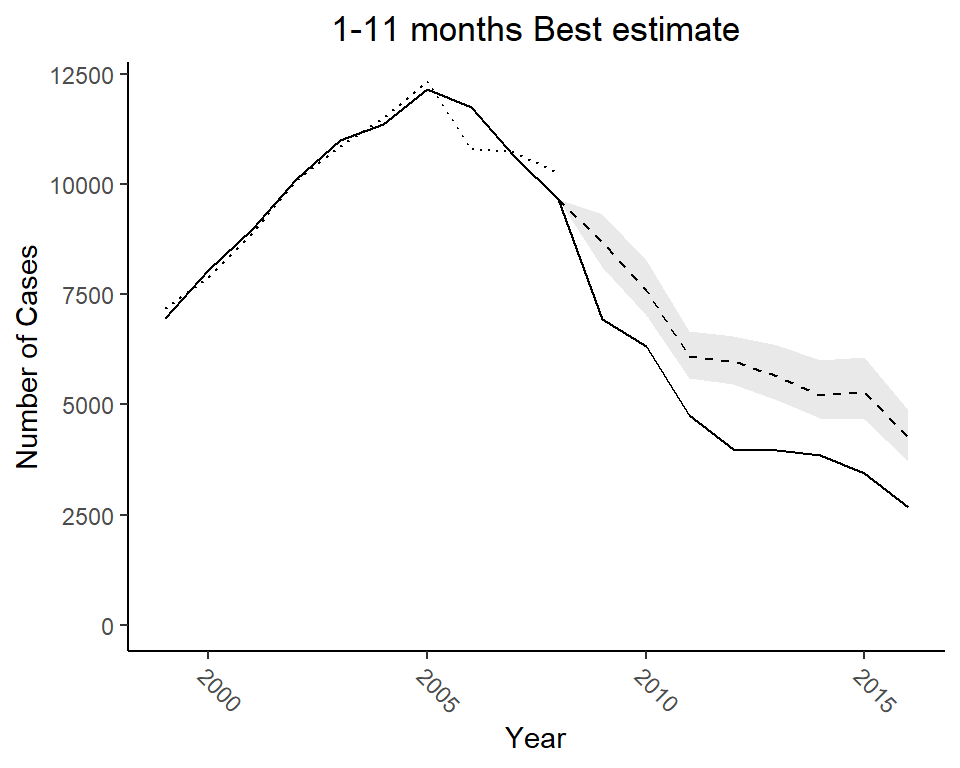

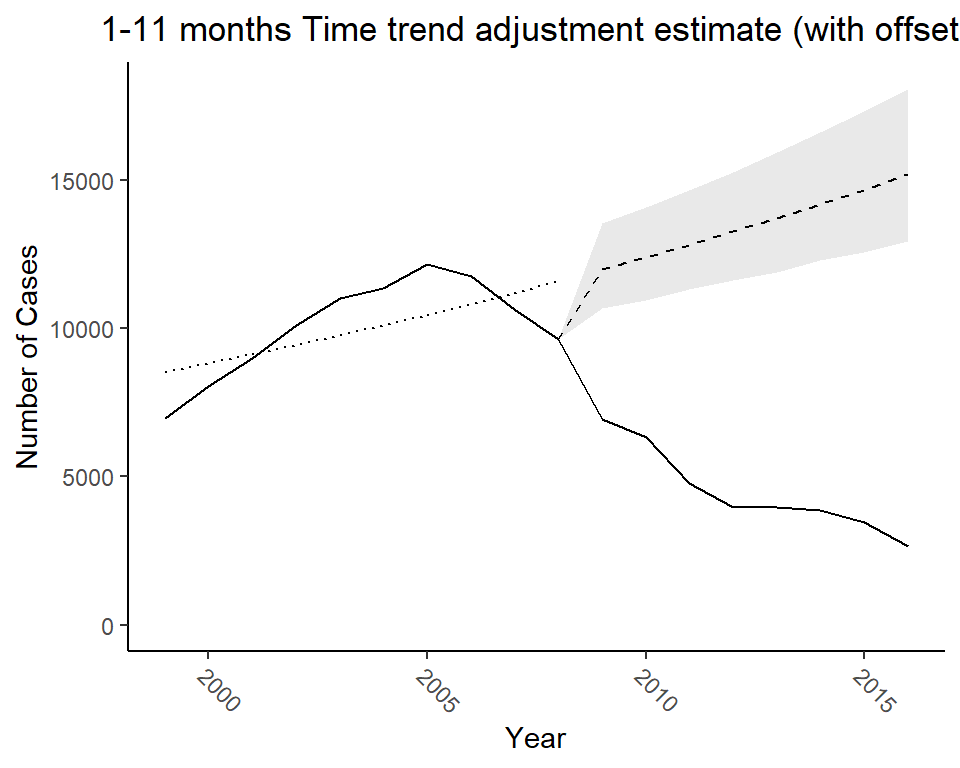

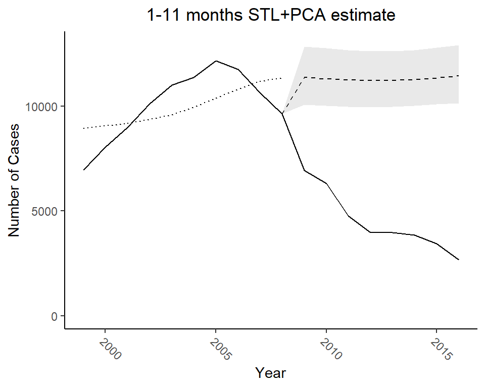

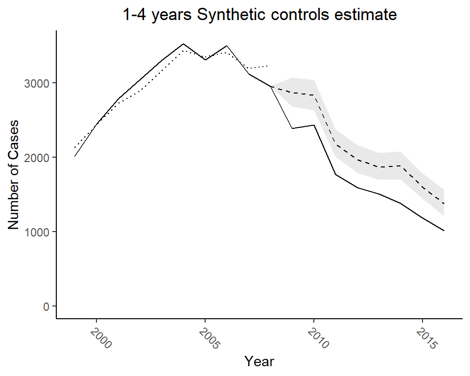

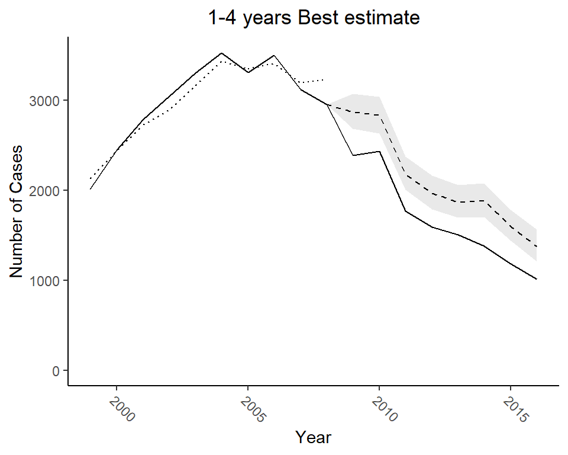

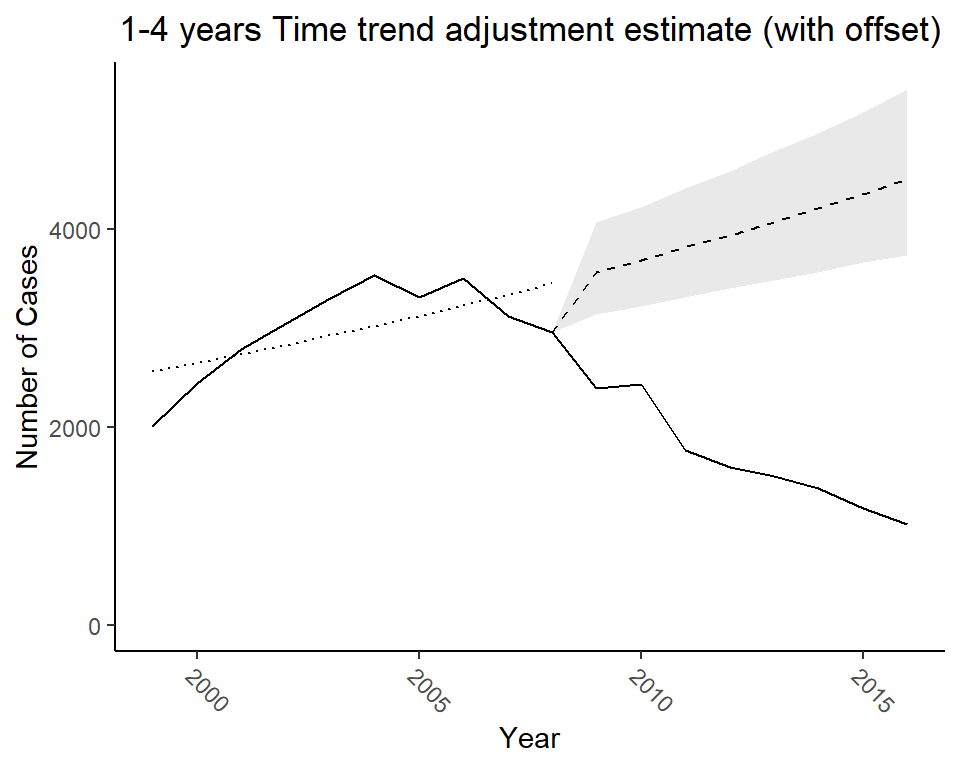

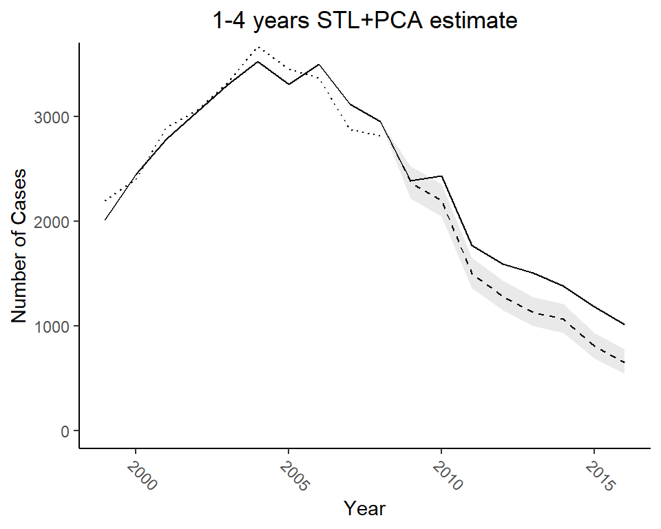

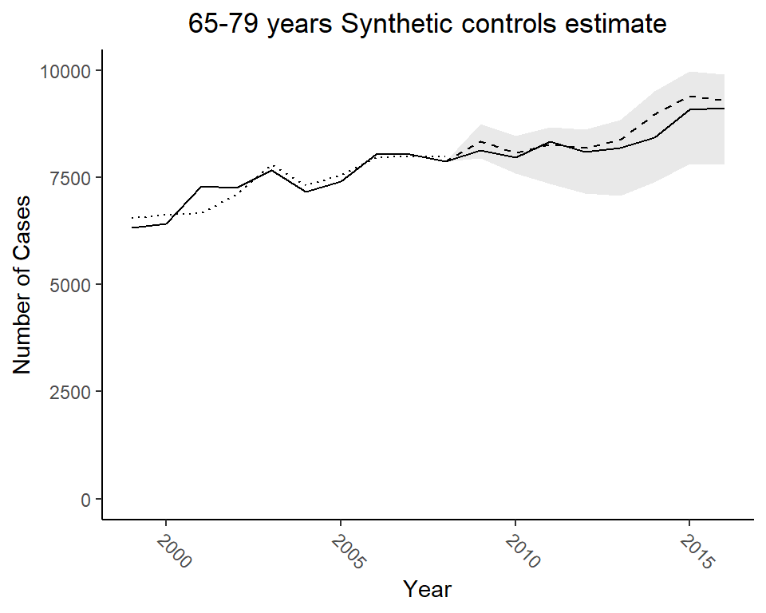

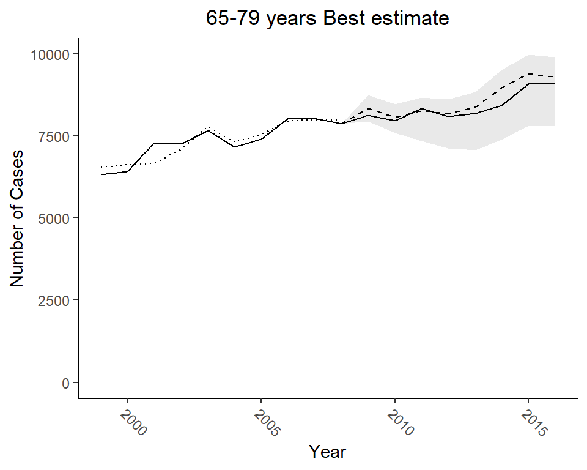

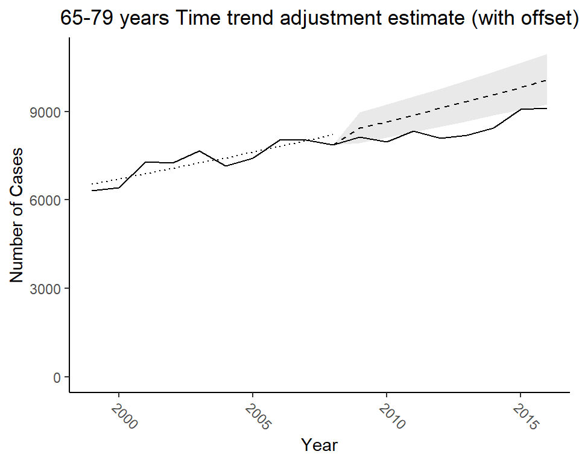

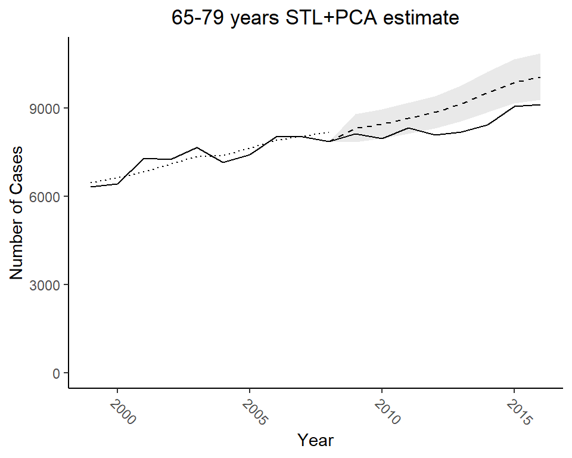

```r
      par(mfrow=c(4,1))

for (group in names(plots$groups)) {
      print(plots$groups[[group]]$pred_full_agg )
      print(plots$groups[[group]]$pred_best_agg )
      print(plots$groups[[group]]$pred_time_agg )
      print(plots$groups[[group]]$pred_pca_agg )
}
```